# Practice: 07/01/2025

Author

Dr. Seals

```r
# use this code chunk to call in all packages the document will need
library(tidyverse)
library(ssstats)
```

## Part 1

**Twilight Sparkle has been working tirelessly on developing a new memory-enhancing spell that she believes could help ponies improve their ability to recall important information. She designs a controlled experiment where each participating pony will complete the same memory test both before and after the spell is cast. By comparing each pony’s performance before and after the treatment, Twilight hopes to determine whether her spell truly boosts memory or if any observed changes are simply due to chance. Twilight records the number of items each pony can remember in both sessions and she is particularly interested in whether the differences in memory scores after the spell show consistent improvement across her group of test subjects.**

**1. Is this independent or dependent data? Why?**

Dependent - before and after on the same pony.

**2. Find the appropriate summary statistics for the data.**

```r
twilight_memory_pt1 %>% dependent_mean_median(before, after)
```

| Variable | Mean (SD) | Median (IQR) |
| --- | --- | --- |
| after – before | 3.12 (1.879) | 3 (2) |
| before | 12.433 (3.053) | 12 (4) |
| after | 15.553 (3.819) | 16 (5) |

**3. What is the appropriate *t*-test?**

Dependent *t*-test.

```r
twilight_memory_pt1 %>% dependent_mean_CI(after, before)
```

```
The point estimate for the mean difference is x̄ = 3.12.
The point estimate for the standard deviation of differences is s = 1.8786.
The 95% confidence interval for the mean difference μ_d is (2.8169, 3.4231).
```

**5. Use the appropriate *t*-test, as identified in Q3, to determine if the data imply an improvement in the memory scores. Test at the $\alpha=0.01$ level.**

```r
twilight_memory_pt1 %>% dependent_mean_HT(after, before,
                                          alternative = "greater",
                                          alpha = 0.01)
```

```
Paired t-test for the mean of differences:
Null: H₀: μ_d ≤ 0
Alternative: H₁: μ_d > 0
Test statistic: t(149) = 20.341
p-value: p < 0.001
Conclusion: Reject the null hypothesis (p = < 0.001 < α = 0.01)
```

- **Hypotheses:**
  - $H_0: \ \mu_d \le 0$
  - $H_1: \ \mu_d > 0$
- **Test Statistic and *p*-Value**
  - $t_0 = 20.341$, $p < 0.001$
- **Rejection Region**
  - Reject $H_0$ if $p < \alpha$; $\alpha = 0.01$
- **Conclusion and interpretation**
  - Reject $H_0$ ($p \text{ vs } \alpha \to (< 0.001) < 0.01$). There is sufficient evidence to suggest that there has been an improvement in memory scores.

**6. What is the appropriate nonparametric test?**

Wilcoxon signed rank.

**7. Use the appropriate nonparametric test, as identified in Q6, to determine if the data imply an improvement in the memory scores. Test at the $\alpha=0.01$ level.**

```r
twilight_memory_pt1 %>% dependent_median_HT(after, before,
                                            alternative = "greater",
                                            alpha = 0.01)
```

```
Wilcoxon Signed-Rank Test for the median of differences:
Null: H₀: M_d = 0
Alternative: H₁: M_d > 0
Test statistic: T = 10425
p-value: p < 0.001
Conclusion: Reject the null hypothesis (p = < 0.001 < α = 0.01)
```

**8. Construct the appropriate QQ plot for this dataset and research question.**

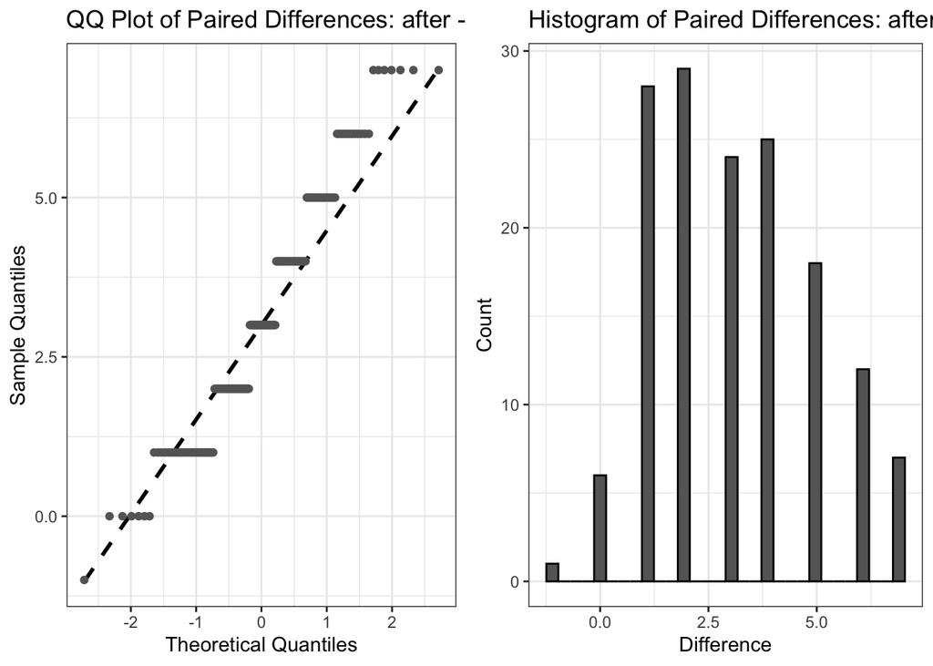

```r
twilight_memory_pt1 %>% dependent_qq(after, before)
```

**9. Determine which test is appropriate. Provide commentary on the graph in Q8 supporting your answer.**

The nonparametric test – the qq plot shows stair steps and not a 45<sup>o</sup> line.

## Part 2

**Twilight Sparkle’s new memory-enhancing spell has quickly gained attention across Equestria, and now she wants to conduct a larger study to compare ponies who receive the spell to those who do not. This time, she recruits two groups of ponies: one group will receive the memory-enhancing spell and the other group will not receive any magical intervention, serving as the control group. By comparing the memory scores between these two groups, Twilight hopes to determine whether the spell leads to a meaningful improvement in memory performance when compared to ponies who did not receive the spell.**

**10. Is this independent or dependent data? Why?**

Independent – the two groups are separate. One group received the spell while the other did not.

**11. Find the appropriate summary statistics for the data.**

```r
twilight_memory_pt2 %>% mean_median(memory_score)
```

```
# A tibble: 1 × 3
  variable     mean_sd    median_iqr
  <chr>        <chr>      <chr>
1 memory_score 13.9 (3.3) 13.9 (4.5)
```

```r
twilight_memory_pt2 %>% group_by(group) %>% mean_median(memory_score)
```

```
# A tibble: 2 × 4
  group     variable     mean_sd    median_iqr
  <chr>     <chr>        <chr>      <chr>
1 1-Spell   memory_score 15.7 (2.9) 15.5 (3.3)
2 2-Control memory_score 12.2 (2.7) 12.0 (3.7)
```

**12. What is the appropriate *t*-test?**

Two-sample *t*-test.

**13. Find the 95% confidence interval for $\boldsymbol{\mu}_1-\boldsymbol{\mu}_2$.**

```r
twilight_memory_pt2 %>% independent_mean_CI(continuous = memory_score,
                                            grouping = group)
```

```
The point estimate for the difference in means is x̄₁ − x̄₂ = 3.4847
The 95% confidence interval for μ₁ − μ₂ is (2.7027, 4.2668)
```

The 95% CI for $\mu_1-\mu_2$ is (2.70, 4.27).

**14. Use the appropriate *t*-test, as identified in Q11, to determine if the data imply an improvement in the memory scores. Test at the $\alpha=0.05$ level.**

```r
twilight_memory_pt2 %>% independent_mean_HT(continuous = memory_score,
                                            grouping = group,
                                            alternative = "greater")
```

```
Two-sample t-test for two independent means and equal variance:
Null: H₀: μ₁ − μ₂ ≤ 0
Alternative: H₁: μ₁ − μ₂ > 0
Test statistic: t(198) = 8.787
p-value: p < 0.001
Conclusion: Reject the null hypothesis (p = < 0.001 < α = 0.05)
```

- **Hypotheses:**
  - $H_0: \ \mu_1 - \mu_2 \le 0$
  - $H_1: \ \mu_1 - \mu_2 > 0$
- **Test Statistic and *p*-Value**
  - $t_0 = 8.787$, $p < 0.001$
- **Rejection Region**
  - Reject $H_0$ if $p < \alpha$; $\alpha = 0.05$
- **Conclusion and interpretation**
  - Reject $H_0$ ($p \text{ vs } \alpha \to (<0.001) < 0.05$). There is sufficient evidence to suggest an improvement in memory scores.

**15. What is the appropriate nonparametric test?**

**16. Use the appropriate nonparametric test, as identified in Q14, to determine if the data imply an improvement in the memory scores. Test at the $\alpha=0.05$ level.**

```r
twilight_memory_pt2 %>% independent_median_HT(continuous = memory_score,
                                              grouping = group,
                                              alternative = "greater")
```

```
Wilcoxon Rank Sum Test for two independent medians
Null: H₀: M₁ - M₂ ≤ 0
Alternative: H₁: M₁ - M₂ > 0
Test statistic: T = 8184
p-value: p < 0.001
Conclusion: Reject the null hypothesis (p = < 0.001 < α = 0.05)
```

- **Hypotheses:**
  - $H_0: \ M_1 - M_2 \le 0$
  - $H_1: \ M_1 - M_2 > 0$
- **Test Statistic and *p*-Value**
  - $T_0 = 8184$, $p < 0.001$
- **Rejection Region**
  - Reject $H_0$ if $p < \alpha$; $\alpha = 0.05$
- **Conclusion and interpretation**
  - Reject $H_0$ ($p \text{ vs } \alpha \to (<0.001) < 0.05$). There is sufficient evidence to suggest an improvement in memory scores.

**17. Construct the appropriate QQ plot for this dataset and research question.**

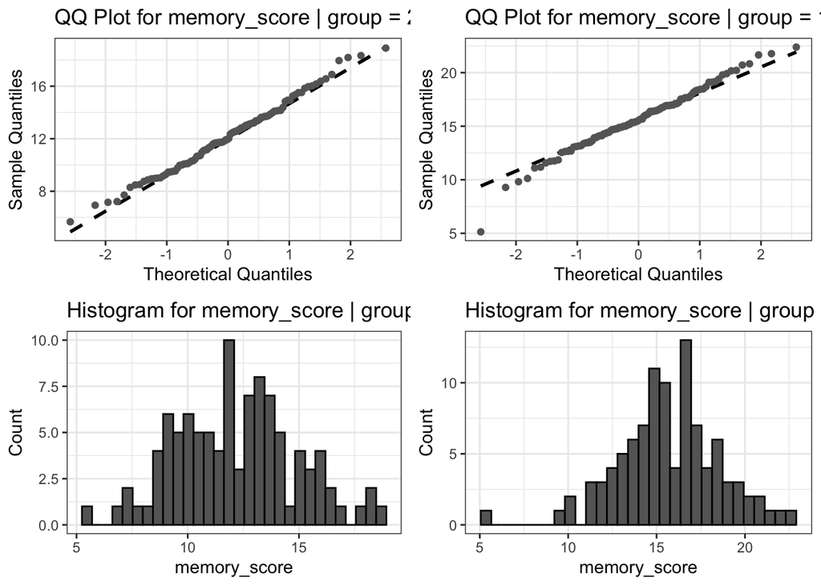

```r
twilight_memory_pt2 %>% independent_qq(continuous = memory_score,
                                       grouping = group)
```

**18. Determine which test is appropriate. Provide commentary on the graph in Q16 supporting your answer.**

The two-sample *t*-test; the qq plots and histograms show normality.